# Text Analytics (Part 2)

Stefano Galelli

Term 6, 2020

First, we prepare the working environment.

```r
rm(list=ls()) # Clear the environment
setwd("~/Documents/SUTD/Term 6/TAE/W10")
# setwd("...")  # Setup the working directory
```

# 1 Data Preparation

Load the Enron data. With the option `stringsAsFactors=FALSE` we make sure that character vectors are not converted into factors.

```r
energy <- read.csv("energy_bid.csv", stringsAsFactors = FALSE)
str(energy)
```

```
## 'data.frame':    851 obs. of  2 variables:
##  $ email     : chr  "North America's integrated electricity market requires cooperation on environmental policies Commission for Env"| __truncated__ "FYI -----Original Message----- From: \t\"Ginny Feliciano\" <gfeliciano@earthlink.net>@ENRON [mailto:IMCEANOTES-"| __truncated__ "14:13:53 Synchroni…
##  $ responsive: int  0 1 0 1 0 0 1 0 0 0 ...
```

```r
# head(energy)
```

The dataframe contains a total of 851 emails, where `energy$email` is the email content, and `energy$responsive` is 1 if the email was responsive (to a query about energy bids and schedules) and 0 otherwise.

Let’s take a look to a few emails:

```r
energy$email[1] # list out the entire email (but this is hard to read).
```

```
## [1] "North America's integrated electricity market requires cooperation on environmental policies Commission for Environmental Cooperation releases working paper on North America's electricity market Montreal, 27 November 2001 -- The North American Commission for Environmental Cooperation (CEC) i…
```

Let’s try with the function `strwrap`, which wraps character strings to format paragraphs easy to read.

```r
# ?strwrap
strwrap(energy$email[1])
```

```
##  [1] "North America's integrated electricity market requires cooperation on"
##  [2] "environmental policies Commission for Environmental Cooperation"
##  [3] "releases working paper on North America's electricity market Montreal,"
##  [4] "27 November 2001 -- The North American Commission for Environmental"
##  [5] "Cooperation (CEC) is releasing a working paper highlighting the trend"
##  [6] "towards increasing trade, competition and cross-border investment in"
##  [7] "electricity between Canada, Mexico and the United States. It is hoped"
##  [8] "that the working paper, Environmental Challenges and Opportunities in"
##  [9] "the Evolving North American Electricity Market, will stimulate public"
## [10] "discussion around a CEC symposium of the same title about the need to"
## [11] "coordinate environmental policies trinationally as a North America-wide"
## [12] "electricity market develops. The CEC symposium will take place in San"
## [13] "Diego on 29-30 November, and will bring together leading experts from"
## [14] "industry, academia, NGOs and the governments of Canada, Mexico and the"
## [15] "United States to consider the impact of the evolving continental"
```

[output cut: 67 more lines]

```r
energy$responsive[1] # This takes value 0 since the email is not responsive to energy bid and schedule.
```

```
## [1] 0
```

```r
strwrap(energy$email[4])
```

```
##  [1] "^ ----- Forwarded by Steven J Kean/NA/Enron on 03/02/2001 12:27 PM"
##  [2] "----- Suzanne_Nimocks@mckinsey.com Sent by: Carol_Benter@mckinsey.com"
##  [3] "03/02/2001 12:04 PM To: skean@enron.com cc: Subject: California Power"
##  [4] "Markets Sorry that we haven't talked in some time.  I thought that you"
##  [5] "would want to take a look at some analysis we have recently completed"
##  [6] "with regard to the California Power Crisis.  You may find some of the"
##  [7] "analysis to be helpful.  Let me know if you have any questions. (See"
##  [8] "attached file: 10209 zxd414.ppt)"
##  [9] "+-------------------------------------------------------------+"
## [10] "***********"
```

```r
energy$responsive[4] # The fourth email deals with the search on the energy bids and schedules. hence, the responsive variable takes a value of 1.
```

```
## [1] 1
```

How many emails are responsive?

```r
table(energy$responsive)
```

```
##
##   0   1
## 714 137
```

That’s about `16.0987074`%.

# 2 Pre-processing

Load the `tm` and `SnowballC` packages:

```r
if(!require(tm)){
  install.packages("tm")
  library(tm)
}

if(!require(SnowballC)){
  install.packages("SnowballC")
  library(SnowballC)
}
```

Create a corpus (a collection of emails, in our case):

```r
corpus <- Corpus(VectorSource(energy$email))
```

Let’s check one of the emails:

```r
as.character(corpus[[4]]) # We check the fourth entry
```

```
## [1] "^ ----- Forwarded by Steven J Kean/NA/Enron on 03/02/2001 12:27 PM ----- Suzanne_Nimocks@mckinsey.com Sent by: Carol_Benter@mckinsey.com 03/02/2001 12:04 PM \t   To: skean@enron.com  cc:   Subject: California Power Markets Sorry that we haven't talked in some time.  I thought that you would …
```

```r
strwrap(as.character(corpus[[4]])) # Read the email in the corpus
```

```
##  [1] "^ ----- Forwarded by Steven J Kean/NA/Enron on 03/02/2001 12:27 PM"
##  [2] "----- Suzanne_Nimocks@mckinsey.com Sent by: Carol_Benter@mckinsey.com"
##  [3] "03/02/2001 12:04 PM To: skean@enron.com cc: Subject: California Power"
##  [4] "Markets Sorry that we haven't talked in some time.  I thought that you"
##  [5] "would want to take a look at some analysis we have recently completed"
##  [6] "with regard to the California Power Crisis.  You may find some of the"
##  [7] "analysis to be helpful.  Let me know if you have any questions. (See"
##  [8] "attached file: 10209 zxd414.ppt)"
##  [9] "+-------------------------------------------------------------+"
## [10] "***********"
```

Make lower case, remove english stopwords, remove punctuation and numbers, and stem.

```r
corpus <- tm_map(corpus, content_transformer(tolower)) # because R is case-sensitive
corpus <- tm_map(corpus, removeWords, stopwords("english"))
corpus <- tm_map(corpus, removePunctuation)
corpus <- tm_map(corpus, removeNumbers)
corpus <- tm_map(corpus, stemDocument) # reduce all variations of words to root words
```

Let’s check the fourth email: note that it is much harder to read … but it is more suitable to apply analytics!

```r
strwrap(energy$email[4])
```

```
##  [1] "^ ----- Forwarded by Steven J Kean/NA/Enron on 03/02/2001 12:27 PM"
##  [2] "----- Suzanne_Nimocks@mckinsey.com Sent by: Carol_Benter@mckinsey.com"
##  [3] "03/02/2001 12:04 PM To: skean@enron.com cc: Subject: California Power"
##  [4] "Markets Sorry that we haven't talked in some time.  I thought that you"
##  [5] "would want to take a look at some analysis we have recently completed"
##  [6] "with regard to the California Power Crisis.  You may find some of the"
##  [7] "analysis to be helpful.  Let me know if you have any questions. (See"
##  [8] "attached file: 10209 zxd414.ppt)"
##  [9] "+-------------------------------------------------------------+"
## [10] "***********"
```

```r
strwrap(as.character(corpus[[4]]))
```

```
## [1] "forward steven j keannaenron pm suzannenimocksmckinseycom sent"
## [2] "carolbentermckinseycom pm skeanenroncom cc subject california power"
## [3] "market sorri talk time thought want take look analysi recent complet"
## [4] "regard california power crisi may find analysi help let know question"
## [5] "see attach file zxdppt"
```

We create a Document-Term matrix from the corpus: we will have 851 documents (rows) and (about) 13798 terms (columns).

```r
dtm <- DocumentTermMatrix(corpus)
dtm
```

```
## <<DocumentTermMatrix (documents: 851, terms: 13798)>>
## Non-/sparse entries: 73158/11668940
## Sparsity           : 99%
## Maximal term length: 112
## Weighting          : term frequency (tf)
```

The matrix is very sparse (99%)!

Let’s inspect the fourth email to see which are the non-zero terms:

```r
inspect(dtm[4,])
```

```
## <<DocumentTermMatrix (documents: 1, terms: 13798)>>
## Non-/sparse entries: 33/13765
## Sparsity           : 100%
## Maximal term length: 112
## Weighting          : term frequency (tf)
## Sample             :
##     Terms
## Docs analysi california help market may power question regard take want
##    4       2          2    1      1   1     2        1      1    1    1
```

Finally, we remove all terms that do not occur in at least 3% of documents.

```r
dtm <- removeSparseTerms(dtm,0.97)
dtm
```

```
## <<DocumentTermMatrix (documents: 851, terms: 612)>>
## Non-/sparse entries: 37960/482852
## Sparsity           : 93%
## Maximal term length: 19
## Weighting          : term frequency (tf)
```

We now have 612 terms left.

# 3 Preparing the DTM for model learning

We transform the term-document matrix into a matrix and, then, into a dataframe:

```r
energysparse <- as.data.frame(as.matrix(dtm))
```

This helps ensure that columns have valid names:

```r
colnames(energysparse) <- make.names(colnames(energysparse))
# str(energysparse)
```

Basic visualization with wordcloud

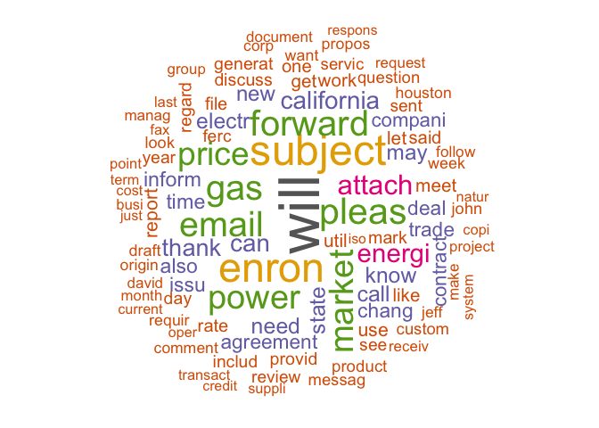

```r
# Load the wordcloud package
if(!require(wordcloud)){
  install.packages("wordcloud")
  library(wordcloud)
}

# Get word counts in decreasing order
word_freqs = sort(colSums(energysparse), decreasing = TRUE)
# Create data frame with words and their frequencies
dm = data.frame(word = names(word_freqs), freq = unname(word_freqs))
# Plot wordcloud (we limit the plot to 100 words)
wordcloud(dm$word, dm$freq, random.order = FALSE, colors = brewer.pal(8, "Dark2"), max.words = 100)
```

Last step, we add the output variable (response) to the `energysparse` dataframe:

```r
energysparse$responsive <- energy$responsive
# str(energysparse)
```

# 4 Train and test a classifier

Let’s prepare the data for our modelling exercise:

```r
# Load the caTools package and set the seed
if(!require(caTools)){
  install.packages("caTools")
  library(caTools)
}

set.seed(123)
# Create train and test sets (with balanced response)
spl   <- sample.split(energysparse$responsive, SplitRatio = 0.7)
train <- subset(energysparse, spl == TRUE)
test  <- subset(energysparse, spl == FALSE)
```

## 4.1 CART

Train:

```r
library(rpart)
model1 <- rpart(as.factor(responsive) ~ ., data = train)
```

Visualize:

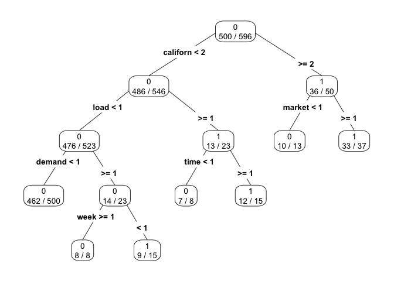

```r
library(rpart.plot)
prp(model1, type = 4, extra = 2)
```

Prediction:

```r
predict1 <- predict(model1, newdata = test, type = "class")
table(predict1, test$responsive)
```

```
##
## predict1   0   1
##        0 205  29
##        1   9  12
```

The model accuracy is 0.8509804.

Should we prune the tree? To answer this question, we look at the `cp` table:

```r
printcp(model1)
```

```
##
## Classification tree:
## rpart(formula = as.factor(responsive) ~ ., data = train)
##
## Variables actually used in tree construction:
## [1] california demand     load       market     time       week
##
## Root node error: 96/596 = 0.16107
##
## n= 596
##
##         CP nsplit rel error  xerror     xstd
## 1 0.229167      0   1.00000 1.00000 0.093482
## 2 0.072917      1   0.77083 0.86458 0.088045
## 3 0.046875      2   0.69792 0.78125 0.084344
## 4 0.015625      4   0.60417 0.77083 0.083860
## 5 0.010000      6   0.57292 0.75000 0.082878
```

It looks like the cross-validation error (`xerror`) has not reached a local minimum yet. This is a situation similar to the one we experienced in the previous session. One option is to then grow a deeper tree and look for the minimum value of `xerror`, on the basis of which we prune the tree.

## 4.2 Random Forests

Train:

```r
library(randomForest)
model2 <- randomForest(as.factor(responsive) ~ ., data = train)
model2
```

```
##
## Call:
##  randomForest(formula = as.factor(responsive) ~ ., data = train)
##                Type of random forest: classification
##                      Number of trees: 500
## No. of variables tried at each split: 24
##
##         OOB estimate of  error rate: 12.92%
## Confusion matrix:
##     0  1 class.error
## 0 484 16   0.0320000
## 1  61 35   0.6354167
```

```r
# summary(model2)
```

Variable importance:

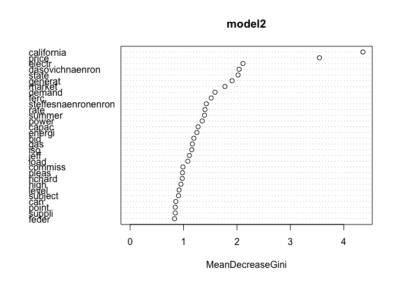

```r
varImpPlot(model2)
```

Prediction

```r
predict2 <- predict(model2, newdata = test, type = "class")
table(predict2, test$responsive)
```

```
##
## predict2   0   1
##        0 212  30
##        1   2  11
```

The model accuracy is 0.8745098.

Find out which predictor variables are actually used in the random forest.

```r
# ?varUsed
# varUsed(model2)
order2 <- sort(varUsed(model2), decreasing = TRUE, index.return = TRUE) # Return sorted frequency and indices
# head(order2$ix)
names(test[,head(order2$ix)]) # we can see which words are important!
```

```
## [1] "pleas"   "subject" "forward" "attach"  "will"    "thank"
```

```r
# returns what are the terms used as determinant in the tree nodes
```

## 4.3 Comparison between CART and RF

Run the models and calculate …

```r
library(ROCR)

predictprob1 <- predict(model1, newdata = test, type = "prob")
predictprob2 <- predict(model2, newdata = test, type = "prob")
pred1 <- prediction(predictprob1[,2], test$responsive)
pred2 <- prediction(predictprob2[,2], test$responsive)
# performance(pred1,measure="auc")
# performance(pred2,measure="auc")
```

Graphical analysis:

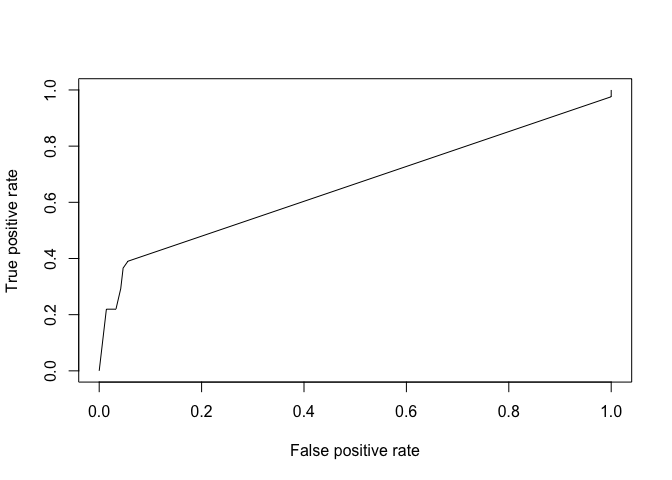

```r
plot(performance(pred1, measure = "tpr", x.measure = "fpr"))
```

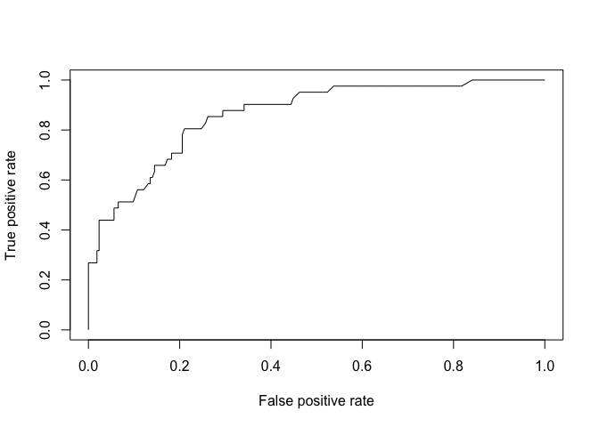

```r
plot(performance(pred2, measure = "tpr", x.measure = "fpr"))
```

For this specific dataset, it appears that Random Forests have a better performance than CARTs.

## 4.4 Naive Bayes Classifier

The function `naiveBayes` (package `e1071`) computes the conditional a-posteriori probabilities of a categorical class variable given independent predictor variables using the Bayes rule.

```r
if(!require(e1071)){
  install.packages("e1071")
  library(e1071)
}

model3 <- naiveBayes(as.factor(responsive) ~ ., data = train)
summary(model3)
```

```
##           Length Class  Mode
## apriori     2    table  numeric
## tables    612    -none- list
## levels      2    -none- character
## isnumeric 612    -none- logical
## call        4    -none- call
```

```r
model3$apriori
```

```
## Y
##   0   1
## 500  96
```

Conditional probabilities for each predictor. For each predictor, we get target class, mean and standard deviation. Let’s look, for example, at the predictor `california` or `market`.

```r
model3$tables$california
```

```
##    california
## Y       [,1]      [,2]
##   0 0.154000 0.8898695
##   1 2.677083 4.5037874
```

```r
model3$tables$market
```

```
##    market
## Y       [,1]     [,2]
##   0 0.464000 2.260736
##   1 3.114583 6.176134
```

```r
# mean, standard deviation
```

Prediction:

```r
predict3 <- predict(model3, newdata = test, type = "class")
table(predict3, test$responsive)
```

```
##
## predict3   0   1
##        0 197  22
##        1  17  19
```

The model accuracy is 0.8470588, roughly comparable to CARTs.